# Metropolis Hastings_Linear Regression

Gordon Goodwin

8/11/2021

## Define True Parameters and Generate Test/Sample Data

We define the “true” underlying parameters for the linear model

- y.i = alpha + B*x.i + e.i ~ N(0,sd)

Then we generate test data that simulates a sample from the population

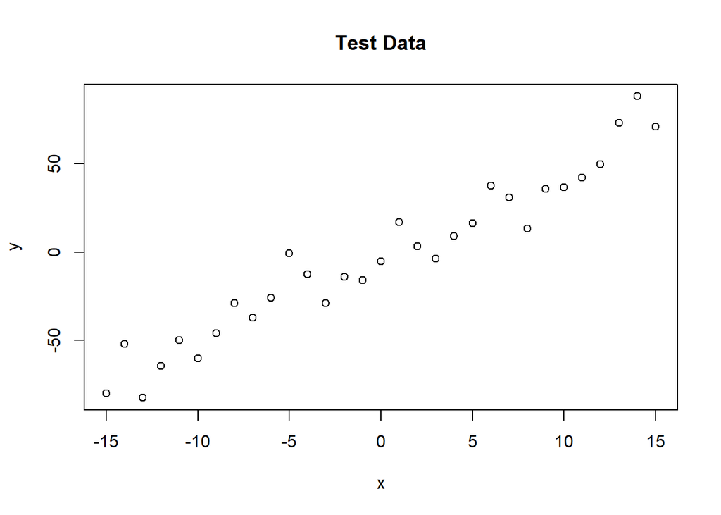

```r
true.b <- 5
true.alpha <- 0
true.sd <- 10
N <- 31
x <-(-15:15)

y <-  true.alpha + true.b * x + rnorm(n=N,mean=0,sd=true.sd)

plot(x,y, main="Test Data")
```

## Specify Generative Model and Likelihood Function

We know what the underlying population parameters are, so let’s fit the model and compare the coefficient estimates based on our sample to the true parameters

- First we need the likelihood function
- p(y | theta) -> p(y|Bx)

We model our errors as being distributed normally around zero, which is the same as modeling the actual y.i values as normally distributed around y.hat (B*x)

- We can approach this by using dnorm(e.i, zero, sd) or dnorm(y.i, Bx, sd)

The function below takes in a theta vector (specific set of parameter values) and outputs the log likelihood of the observed y.i values given the param values

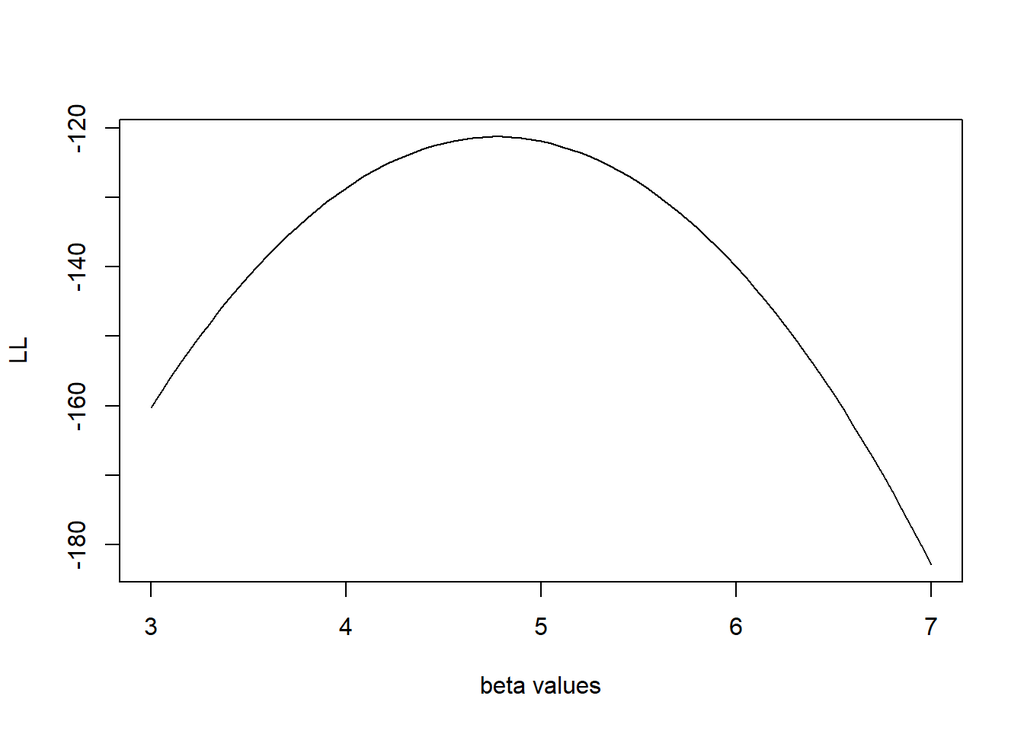

```r
likelihood <- function(param){

    alpha = param[1]
    beta = param[2]
    sd = param[3]

    y.hat = alpha + beta*x
    ind.LL = dnorm(y, mean = y.hat, sd = sd, log = T)
    LL = sum(ind.LL)
    return(LL)
}

# Example: plot the likelihood profile of the slope (beta)
beta.LLfun <- function(b){return(likelihood(c(true.alpha, b, true.sd)))}
beta.LLres <- lapply(seq(3, 7, by=.05), beta.LLfun )
plot (seq(3, 7, by=.05), beta.LLres , type="l", xlab = "beta values", ylab = "LL")
```

## Specify Prior

We will use uninformative prior distributions

- intercept ~ N(0, 1000)
- beta.1 ~ N(0, 1000)
- sd ~ invgamma(1, 1)

```r
prior <- function(param){

    alpha = param[1]
    beta = param[2]
    sd = param[3]


    pr.alpha = dnorm(alpha, mean = 0, sd = 1000, log = T)
    pr.beta = dnorm(beta, mean = 0, sd = 1000, log = T)
    pr.sd = dinvgamma(sd, 1, 1, log = T)
    pr.theta = sum(pr.alpha, pr.beta, pr.sd)
    return(pr.theta)
}
```

## Specifying the Posterior

Because we are using MCMC to approximate the posterior, we don’t need to use the normalized posterior.

- p(theta | y) is proportional to p(theta, y) -> p(y|theta) * p(theta)

```r
posterior <- function(param){
   return (likelihood(param) + prior(param))
}
```

## MCMC Metropolis Hastings

Here comes the fun part! Now we use the MH algo to sample from the joint posterior

- MH algo samples from parameter space with a frequency proportional to the probability of p(theta | y)
- Approximated via p(theta, y) -> joint posterior -> prior * LL

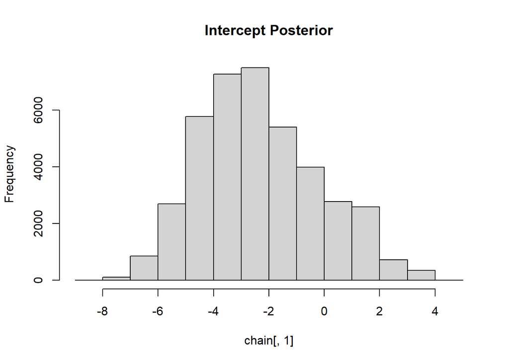

```r
propose <- function(param){
    return(rnorm(3,mean = param, sd= c(0.1,0.5,0.3)))
}

MCMC_MH <- function(startval, iterations){
    chain = array(dim = c(iterations+1,3))                # Structure of Array
    chain[1,] = startval                              # Establish Loop
    for (i in 1:iterations){
        proposal = propose(chain[i,])   # Propose theta[i+1] based on theta[i]

        accept = exp(posterior(proposal) - posterior(chain[i,]))
        if (runif(1) < accept){     #AR <-Post(theta[i+1]) to Post(theta[i])
            chain[i+1,] = proposal
        }else{
            chain[i+1,] = chain[i,]
        }
    }
    return(chain)
}

startval = c(4,0,10)
chain = MCMC_MH(startval, 40000)

burnIn = 1000
acceptance = 1-mean(duplicated(chain[-(1:burnIn),]))


hist(chain[,1], main = "Intercept Posterior")
```

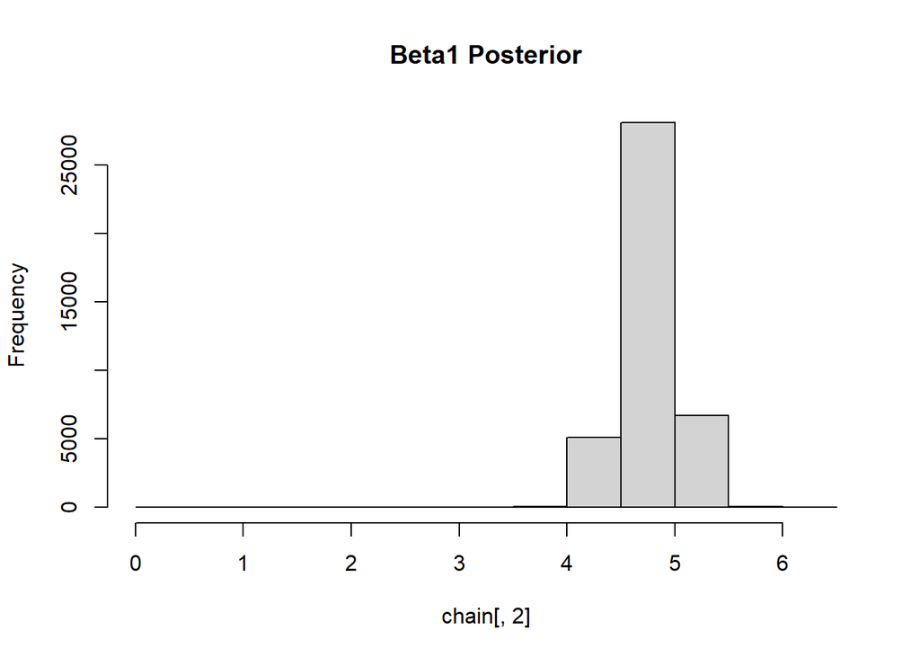

```r
hist(chain[,2], main = "Beta1 Posterior")
```

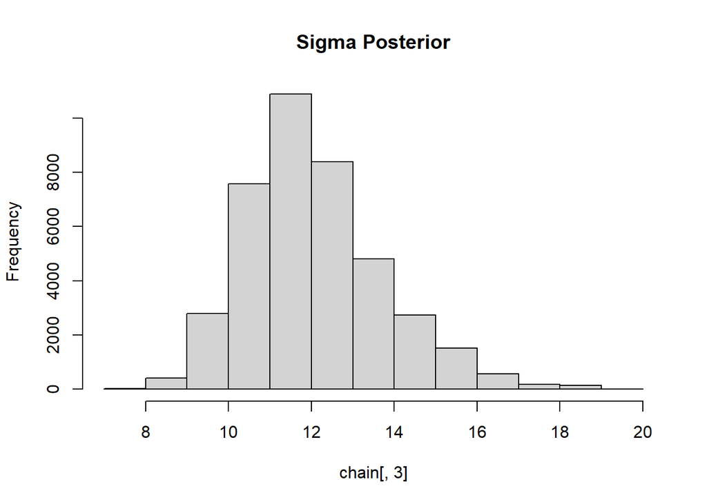

```r
hist(chain[,3], main = "Sigma Posterior")
```

## Plotting the Results

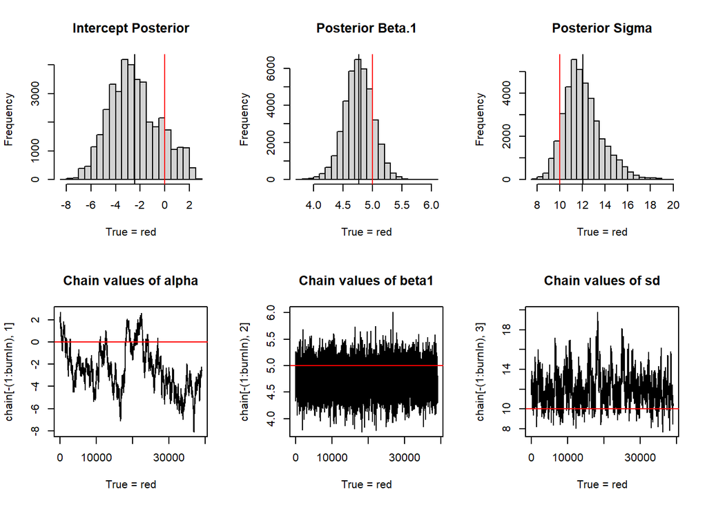

```r
par(mfrow = c(2,3))
hist(chain[-(1:burnIn),1],nclass=30, main="Intercept Posterior", xlab="True = red")
abline(v = mean(chain[-(1:burnIn),1]))
abline(v = true.alpha, col="red" )
hist(chain[-(1:burnIn),2],nclass=30, main="Posterior Beta.1", xlab="True = red")
abline(v = mean(chain[-(1:burnIn),2]))
abline(v = true.b, col="red" )
hist(chain[-(1:burnIn),3],nclass=30, main="Posterior Sigma", xlab="True = red")
abline(v = mean(chain[-(1:burnIn),3]) )
abline(v = true.sd, col="red" )
plot(chain[-(1:burnIn),1], type = "l", xlab="True = red" , main = "Chain values of alpha", )
abline(h = true.alpha, col="red" )
plot(chain[-(1:burnIn),2], type = "l", xlab="True = red" , main = "Chain values of beta1", )
abline(h = true.b, col="red" )
plot(chain[-(1:burnIn),3], type = "l", xlab="True = red" , main = "Chain values of sd", )
abline(h = true.sd, col="red" )
```